# 모델 구축 및 평가

- 데이터 셋 나누기
- 모델 구축 및 평가 (교차 검증 등)
- 모델별 비교
- 적합한 모델 선택

```python
import os, warnings
import numpy as np
# 경고 메세지 무시하거나 숨길때(ignore), 다시보이게(default)
# warnings.filterwarnings(action='ignore')
warnings.filterwarnings(action='ignore')
```

```python
import pandas as pd
import seaborn as sns
import matplotlib.pyplot as plt
```

### 데이터 분할 및 특성 선택

### 데이터 전처리

```python
# 데이터 읽기
train = pd.read_csv('data/train.csv')
test = pd.read_csv('data/test.csv')

# 결측값 채우기(Age)
train.Age = train.Age.fillna(train.Age.median())
test.Age = test.Age.fillna(train.Age.median())
# 결측값 채우고 숫자형으로 변환(Cabin)
train['Cabin_n'] = train['Cabin'].notnull().astype(int)
test['Cabin_n'] = test['Cabin'].notnull().astype(int)
# 결측값 채우기(train.Embarked)
train.Embarked = train.Embarked.fillna('S')
# 결측값 채우기(test.Fare)
test['Fare'] = test['Fare'].median()

# 데이터 수치형으로 변환(Sex)
train['Sex_n'] = train.Sex.map({'male':1, 'female':2})
test['Sex_n'] = test.Sex.map({'male':1, 'female':2})
# 데이터 수치형으로 변환(Embarked)
train['Embarked_n'] = train['Embarked'].map({'S':1, 'C':2, 'Q':3})
test['Embarked_n'] = test['Embarked'].map({'S':1, 'C':2, 'Q':3})

# 데이터 특성 선택 및 분할
sel = ['Survived', 'Pclass', 'Age', 'SibSp', 'Parch', 'Fare', 'Cabin_n', 'Sex_n', 'Embarked_n']
X = train[sel]
y = train['Survived']
```

### 특성간 상관관계 확인

```python
sel = ['Survived', 'Pclass', 'Age', 'SibSp', 'Parch', 'Fare', 'Cabin_n', 'Sex_n', 'Embarked_n']
```

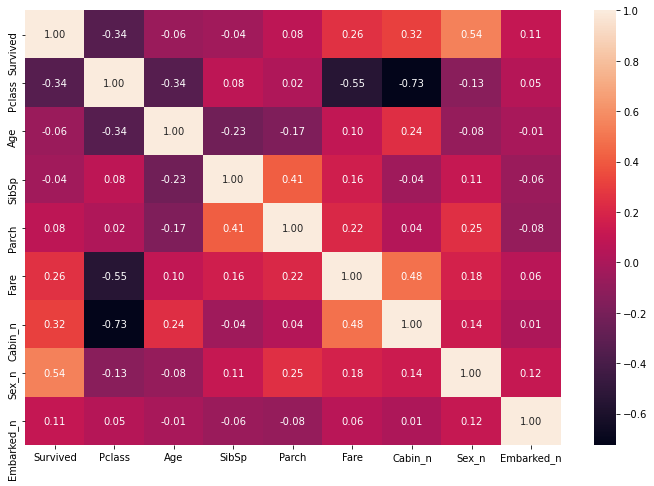

```python
plt.figure(figsize=(12,8))
sns.heatmap(train[sel].corr(), annot=True, fmt='.2f')
```

### 데이터 셋 나누기

```python
from sklearn.model_selection import train_test_split
```

```python
sel = ['Pclass', 'Age', 'SibSp', 'Parch', 'Fare', 'Cabin_n', 'Sex_n', 'Embarked_n']
X = train[sel]
y = train['Survived']

X_train, X_test, y_train, y_test = train_test_split(X, y, stratify=y, random_state=0)
X_train.shape, y_train.shape, X_test.shape, y_test.shape
```

```
((668, 8), (668,), (223, 8), (223,))
```

### 모델 별 비교

- KNN 회귀
- KNN 분류
- LinearRegression
  - Lasso(L1)
  - Ridge(L2)
- DecisionTreeClassifier
- RandomForestClassifier
- LogisticRegression

```python
from sklearn.neighbors import KNeighborsRegressor, KNeighborsClassifier
from sklearn.linear_model import LinearRegression, Lasso, Ridge
from sklearn.tree import DecisionTreeClassifier
from sklearn.ensemble import RandomForestClassifier
from sklearn.linear_model import LogisticRegression
```

### 교차 검증

- KFold, LOOCV

```python
from sklearn.model_selection import cross_val_score, KFold, LeaveOneOut
```

### 모델 훈련, 교차 검증 점수 출력 함수화

```python
def ML_kfold_score(model_name):
    # test_size 변경
    for i in range(1, 6):
        X_train, X_test, y_train, y_test = train_test_split(X, y, stratify=y, test_size = (i/10), random_state=0)
        # 모델 훈련
        model_name.fit(X_train,  y_train)
        # 교차검증
        kfold = KFold()
        # scores = cross_val_score(모델 객체, 입력, 결과, cv = cross_validation)
        score = cross_val_score(model_name, X_test, y_test, cv=kfold)
        print(f"훈련 : 테스트 = {10-i} : {i}")
        print(f"교차 검증 점수 : {score}")
        print("교자 검증 점수 평균 :", score.mean())
        print()
```

### 모델 객체화

```python
# 모델 생성
knn_r = KNeighborsRegressor()
knn_c = KNeighborsClassifier()
lr = LinearRegression()
ls = Lasso()
rdg = Ridge()
dt_c = DecisionTreeClassifier()
rf_c = RandomForestClassifier()
lg_r = LogisticRegression()
```

### 모델 훈련 및 교차검증 점수 출력

## knn 분류 모델1

- 'Age' : median
- test.fare : median
- statify 설정
- 교차검증 : KFold
- 점수
  - 7:3 => 0.7203354297693921
  - 9:1 => 0.6555555555555556

```python
ML_kfold_score(knn_c)
```

```
훈련 : 테스트 = 9 : 1
교차 검증 점수 : [0.72222222 0.72222222 0.94444444 0.38888889 0.5       ]
교자 검증 점수 평균 : 0.6555555555555556

훈련 : 테스트 = 8 : 2
교차 검증 점수 : [0.69444444 0.75       0.75       0.66666667 0.71428571]
교자 검증 점수 평균 : 0.7150793650793651

훈련 : 테스트 = 7 : 3
교차 검증 점수 : [0.74074074 0.59259259 0.77777778 0.75471698 0.73584906]
교자 검증 점수 평균 : 0.7203354297693921

훈련 : 테스트 = 6 : 4
교차 검증 점수 : [0.72222222 0.58333333 0.70422535 0.74647887 0.63380282]
교자 검증 점수 평균 : 0.6780125195618153

훈련 : 테스트 = 5 : 5
교차 검증 점수 : [0.62222222 0.71910112 0.6741573  0.70786517 0.70786517]
교자 검증 점수 평균 : 0.6862421972534332
```

## LinearRegression 모델1

- 'Age' : median
- test.fare : median
- statify 설정
- 교차검증 : KFold
- 점수
  - 7:3 => 0.39134971416091474
  - 9:1 => 0.14193941941865001
  - 정규화, 표준화해서 시도

```python
ML_kfold_score(lr)
```

```
훈련 : 테스트 = 9 : 1
교차 검증 점수 : [ 0.39587365 -0.31346557  0.4139666  -0.30592553  0.51924794]
교자 검증 점수 평균 : 0.14193941941865001

훈련 : 테스트 = 8 : 2
교차 검증 점수 : [0.12725097 0.21353669 0.43692035 0.34453064 0.39453147]
교자 검증 점수 평균 : 0.3033540246685914

훈련 : 테스트 = 7 : 3
교차 검증 점수 : [0.32630154 0.22466858 0.40905241 0.43941405 0.55731199]
교자 검증 점수 평균 : 0.39134971416091474

훈련 : 테스트 = 6 : 4
교차 검증 점수 : [0.48497356 0.37069382 0.28286319 0.44602156 0.33193483]
교자 검증 점수 평균 : 0.3832973929124467

훈련 : 테스트 = 5 : 5
교차 검증 점수 : [0.38589306 0.38595712 0.40817439 0.20012729 0.44777872]
교자 검증 점수 평균 : 0.36558611488348464
```

### 스케일 조정

```python
# 데이터 읽기
train = pd.read_csv('data/train.csv')
test = pd.read_csv('data/test.csv')

# 결측값 채우기(Age)
train.Age = train.Age.fillna(train.Age.median())
test.Age = test.Age.fillna(train.Age.median())
# 결측값 채우고 숫자형으로 변환(Cabin)
train['Cabin_n'] = train['Cabin'].notnull().astype(int)
test['Cabin_n'] = test['Cabin'].notnull().astype(int)
# 결측값 채우기(train.Embarked)
train.Embarked = train.Embarked.fillna('S')
# 결측값 채우기(test.Fare)
test['Fare'] = test['Fare'].median()

# 데이터 수치형으로 변환(Sex)
train['Sex_n'] = train.Sex.map({'male':1, 'female':2})
test['Sex_n'] = test.Sex.map({'male':1, 'female':2})
# 데이터 수치형으로 변환(Embarked)
train['Embarked_n'] = train['Embarked'].map({'S':1, 'C':2, 'Q':3})
test['Embarked_n'] = test['Embarked'].map({'S':1, 'C':2, 'Q':3})

# 데이터 특성 선택 및 분할
sel = ['Pclass', 'Age', 'SibSp', 'Parch', 'Fare', 'Cabin_n', 'Sex_n', 'Embarked_n']
X = train[sel]
y = train['Survived']
```

```python
# 예측 확인
pred = lr.predict(X_test)
pred[:6]
```

```
array([0.18432445, 0.21225898, 0.06667321, 0.05930441, 0.3530594 ,
       0.56416   ])
```

```python
from sklearn.preprocessing import MinMaxScaler, StandardScaler
```

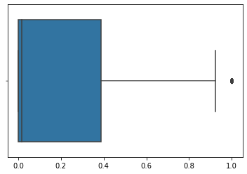

```python
mms = MinMaxScaler()
mms.fit(X)
mms_X_train = mms.transform(X_train)
sns.boxplot(x=mms_X_train)
```

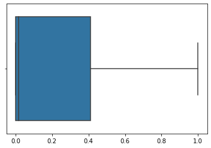

```python
mms_X_test = mms.transform(X_test)
sns.boxplot(x=mms_X_test)
```

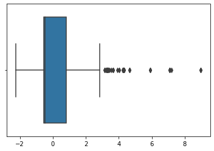

```python
ss = StandardScaler()
ss_mms_X_train = ss.fit_transform(mms_X_train)
sns.boxplot(x=ss_mms_X_train)
```

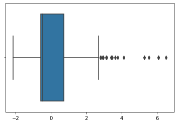

```python
ss_mms_X_test = ss.fit_transform(mms_X_test)
sns.boxplot(x=ss_mms_X_test)
```

```python
pred = lr.predict(ss_mms_X_test)
pred[:6]
```

```
array([0.60728378, 0.06878205, 0.65981515, 0.08738686, 0.58236094,
       0.0619495 ])
```

## LinearRegression 모델1(스케일 조정)

- 'Age' : median
- test.fare : median
- statify 설정
- 스케일 조정 : MinMaxScaler, StandardScaler
- 교차검증 : KFold
- 점수
  - 7:3 => 0.39134971416091474
  - 9:1 => 0.14193941941865001
  - 정규화, 표준화해서 시도

```python
# 데이터 읽기
train = pd.read_csv('data/train.csv')
test = pd.read_csv('data/test.csv')

# 결측값 채우기(Age)
train.Age = train.Age.fillna(train.Age.median())
test.Age = test.Age.fillna(train.Age.median())
# 결측값 채우고 숫자형으로 변환(Cabin)
train['Cabin_n'] = train['Cabin'].notnull().astype(int)
test['Cabin_n'] = test['Cabin'].notnull().astype(int)
# 결측값 채우기(train.Embarked)
train.Embarked = train.Embarked.fillna('S')
# 결측값 채우기(test.Fare)
test['Fare'] = test['Fare'].median()

# 데이터 수치형으로 변환(Sex)
train['Sex_n'] = train.Sex.map({'male':1, 'female':2})
test['Sex_n'] = test.Sex.map({'male':1, 'female':2})
# 데이터 수치형으로 변환(Embarked)
train['Embarked_n'] = train['Embarked'].map({'S':1, 'C':2, 'Q':3})
test['Embarked_n'] = test['Embarked'].map({'S':1, 'C':2, 'Q':3})

# 데이터 특성 선택 및 분할
sel = ['Pclass', 'Age', 'SibSp', 'Parch', 'Fare', 'Cabin_n', 'Sex_n', 'Embarked_n']
X = train[sel]
y = train['Survived']

# test_size 변경
for i in range(1, 6):
    X_train, X_test, y_train, y_test = train_test_split(X, y, stratify=y, test_size = (i/10), random_state=0)
    # 스케일 조정
    # 정규화
    mms = MinMaxScaler()
    mms.fit(X)
    mms_X_train = mms.transform(X_train)
    mms_X_test = mms.transform(X_test)
    # 표준화
    ss = StandardScaler()
    ss_mms_X_train = ss.fit_transform(mms_X_train)
    ss_mms_X_test = ss.fit_transform(mms_X_test)
    # 모델 훈련
    lr.fit(ss_mms_X_train,  y_train)
    # 교차검증
    kfold = KFold()
    # scores = cross_val_score(모델 객체, 입력, 결과, cv = cross_validation)
    score = cross_val_score(lr, ss_mms_X_test, y_test, cv=kfold)
    print(f"훈련 : 테스트 = {10-i} : {i}")
    print(f"교차 검증 점수 : {score}")
    print("교자 검증 점수 평균 :", score.mean())
    print()
```

```
훈련 : 테스트 = 9 : 1
교차 검증 점수 : [ 0.39587365 -0.31346557  0.4139666  -0.30592553  0.51924794]
교자 검증 점수 평균 : 0.14193941941864985

훈련 : 테스트 = 8 : 2
교차 검증 점수 : [0.12725097 0.21353669 0.43692035 0.34453064 0.39453147]
교자 검증 점수 평균 : 0.3033540246685913

훈련 : 테스트 = 7 : 3
교차 검증 점수 : [0.32630154 0.22466858 0.40905241 0.43941405 0.55731199]
교자 검증 점수 평균 : 0.391349714160916

훈련 : 테스트 = 6 : 4
교차 검증 점수 : [0.48497356 0.37069382 0.28286319 0.44602156 0.33193483]
교자 검증 점수 평균 : 0.38329739291244724

훈련 : 테스트 = 5 : 5
교차 검증 점수 : [0.38589306 0.38595712 0.40817439 0.20012729 0.44777872]
교자 검증 점수 평균 : 0.36558611488348486
```

## Lasso 모델1

```python
ML_kfold_score(ls)
```

```
훈련 : 테스트 = 9 : 1
교차 검증 점수 : [ 0.01481521  0.00527443 -0.02813625 -0.66955797 -0.04681014]
교자 검증 점수 평균 : -0.14488294374154756

훈련 : 테스트 = 8 : 2
교차 검증 점수 : [ 0.05047992  0.0471399   0.05350616  0.01734422 -0.19599922]
교자 검증 점수 평균 : -0.005505802915306534

훈련 : 테스트 = 7 : 3
교차 검증 점수 : [-0.02036802 -0.0653666   0.05309664  0.07391112  0.08138247]
교자 검증 점수 평균 : 0.02453112239918558

훈련 : 테스트 = 6 : 4
교차 검증 점수 : [0.03433132 0.02202754 0.0255569  0.05484923 0.01838532]
교자 검증 점수 평균 : 0.031030060797986335

훈련 : 테스트 = 5 : 5
교차 검증 점수 : [-0.0070493   0.06529901  0.02828397  0.02473389  0.05724537]
교자 검증 점수 평균 : 0.03370258852703785
```

## Ridge 모델1

- 'Age' : median
- test.fare : median
- statify 설정
- 교차검증 : KFold()
- 점수
  - 7:3 => 0.3912594474773294
  - 9:1 => 0.14684937152057873

```python
ML_kfold_score(rdg)
```

```
훈련 : 테스트 = 9 : 1
교차 검증 점수 : [ 0.38881681 -0.27857527  0.41908435 -0.2804148   0.48533576]
교자 검증 점수 평균 : 0.14684937152057873

훈련 : 테스트 = 8 : 2
교차 검증 점수 : [0.13198651 0.22700283 0.43558694 0.34079696 0.38691746]
교자 검증 점수 평균 : 0.30445814264970167

훈련 : 테스트 = 7 : 3
교차 검증 점수 : [0.32702487 0.22730459 0.40907735 0.43682229 0.55606813]
교자 검증 점수 평균 : 0.3912594474773294

훈련 : 테스트 = 6 : 4
교차 검증 점수 : [0.48458427 0.37070113 0.2838601  0.44626596 0.33270376]
교자 검증 점수 평균 : 0.3836230433936975

훈련 : 테스트 = 5 : 5
교차 검증 점수 : [0.38562432 0.38657373 0.40663699 0.20379767 0.44696622]
교자 검증 점수 평균 : 0.36591978615823845
```

```python
# 예측 확인
pred = ls.predict(X_test)
pred[:6]
```

```
array([0.81703478, 0.34250925, 0.32716468, 0.32602028, 0.32716468,
       0.32416062])
```

## DecisionTreeClassifier 모델1

- 'Age' : median
- test.fare : median
- statify 설정
- 교차검증 : KFold()
- 점수
  - 7:3 => 0.7797344514325646
  - 9:1 => 0.6666666666666667

```python
ML_kfold_score(dt_c)
```

```
훈련 : 테스트 = 9 : 1
교차 검증 점수 : [0.72222222 0.55555556 0.72222222 0.61111111 0.72222222]
교자 검증 점수 평균 : 0.6666666666666667

훈련 : 테스트 = 8 : 2
교차 검증 점수 : [0.58333333 0.72222222 0.72222222 0.63888889 0.71428571]
교자 검증 점수 평균 : 0.6761904761904762

훈련 : 테스트 = 7 : 3
교차 검증 점수 : [0.77777778 0.81481481 0.77777778 0.77358491 0.75471698]
교자 검증 점수 평균 : 0.7797344514325646

훈련 : 테스트 = 6 : 4
교차 검증 점수 : [0.75       0.75       0.70422535 0.78873239 0.63380282]
교자 검증 점수 평균 : 0.7253521126760563

훈련 : 테스트 = 5 : 5
교차 검증 점수 : [0.71111111 0.78651685 0.73033708 0.70786517 0.75280899]
교자 검증 점수 평균 : 0.7377278401997502
```

```python
# 예측 확인
pred = dt_c.predict(X_test)
pred[:6]
```

```
array([0, 0, 0, 0, 1, 0], dtype=int64)
```

## RandomForestClassifier 모델1

- 'Age' : median
- test.fare : median
- statify 설정
- 교차검증 : KFold()
- 점수
  - 7:3 => 0.7872816212438853
  - 9:1 => 0.688888888888889

```python
ML_kfold_score(rf_c)
```

```
훈련 : 테스트 = 9 : 1
교차 검증 점수 : [0.66666667 0.55555556 0.83333333 0.55555556 0.83333333]
교자 검증 점수 평균 : 0.688888888888889

훈련 : 테스트 = 8 : 2
교차 검증 점수 : [0.63888889 0.77777778 0.86111111 0.75       0.8       ]
교자 검증 점수 평균 : 0.7655555555555555

훈련 : 테스트 = 7 : 3
교차 검증 점수 : [0.83333333 0.7962963  0.74074074 0.75471698 0.81132075]
교자 검증 점수 평균 : 0.7872816212438853

훈련 : 테스트 = 6 : 4
교차 검증 점수 : [0.79166667 0.77777778 0.76056338 0.77464789 0.69014085]
교자 검증 점수 평균 : 0.7589593114241001

훈련 : 테스트 = 5 : 5
교차 검증 점수 : [0.77777778 0.76404494 0.71910112 0.74157303 0.80898876]
교자 검증 점수 평균 : 0.7622971285892634
```

```python
# 예측 확인
pred = rf_c.predict(X_test)
pred[:6]
```

```
array([0, 0, 0, 0, 1, 0], dtype=int64)
```

## LogisticRegression 모델1

- 'Age' : median
- test.fare : median
- statify 설정
- 교차검증 : KFold()
- 점수
  - 7:3 => 0.8060796645702306
  - 9:1 => 0.7222222222222223

```python
ML_kfold_score(lg_r)
```

```
훈련 : 테스트 = 9 : 1
교차 검증 점수 : [0.83333333 0.61111111 0.83333333 0.5        0.83333333]
교자 검증 점수 평균 : 0.7222222222222223

훈련 : 테스트 = 8 : 2
교차 검증 점수 : [0.66666667 0.66666667 0.80555556 0.77777778 0.77142857]
교자 검증 점수 평균 : 0.7376190476190476

훈련 : 테스트 = 7 : 3
교차 검증 점수 : [0.7962963  0.75925926 0.83333333 0.81132075 0.83018868]
교자 검증 점수 평균 : 0.8060796645702306

훈련 : 테스트 = 6 : 4
교차 검증 점수 : [0.84722222 0.81944444 0.77464789 0.83098592 0.73239437]
교자 검증 점수 평균 : 0.8009389671361502

훈련 : 테스트 = 5 : 5
교차 검증 점수 : [0.77777778 0.83146067 0.80898876 0.69662921 0.86516854]
교자 검증 점수 평균 : 0.7960049937578028
```

```python
# 예측 확인
pred = lg_r.predict(X_test)
pred[:6]
```

```
array([1, 0, 1, 0, 1, 0], dtype=int64)
```

## KFold(shuffle) 교차검증

```python
def ML_kfold_s_score(model_name):
    # test_size 변경
    for i in range(1, 6):
        X_train, X_test, y_train, y_test = train_test_split(X, y, stratify=y, test_size = (i/10), random_state=0)
        # 모델 훈련
        model_name.fit(X_train,  y_train)
        # 교차검증
        kfold = KFold(shuffle=True)
        # scores = cross_val_score(모델 객체, 입력, 결과, cv = cross_validation)
        score = cross_val_score(model_name, X_test, y_test, cv=kfold)
        print(f"훈련 : 테스트 = {10-i} : {i}")
        print(f"교차 검증 점수 : {score}")
        print("교자 검증 점수 평균 :", score.mean())
        print()
```

## knn 분류 모델2

- 'Age' : median
- test.fare : median
- statify 설정
- 교차검증 : KFold(shuffle)
- 점수
  - 7:3 => 0.7202655485674354
  - 9:1 => 0.6777777777777778

```python
ML_kfold_s_score(knn_c)
```

```
훈련 : 테스트 = 9 : 1
교차 검증 점수 : [0.72222222 0.55555556 0.66666667 0.72222222 0.72222222]
교자 검증 점수 평균 : 0.6777777777777778

훈련 : 테스트 = 8 : 2
교차 검증 점수 : [0.61111111 0.72222222 0.66666667 0.61111111 0.8       ]
교자 검증 점수 평균 : 0.6822222222222223

훈련 : 테스트 = 7 : 3
교차 검증 점수 : [0.77777778 0.64814815 0.7037037  0.73584906 0.73584906]
교자 검증 점수 평균 : 0.7202655485674354

훈련 : 테스트 = 6 : 4
교차 검증 점수 : [0.76388889 0.66666667 0.66197183 0.73239437 0.57746479]
교자 검증 점수 평균 : 0.6804773082942097

훈련 : 테스트 = 5 : 5
교차 검증 점수 : [0.68888889 0.74157303 0.62921348 0.69662921 0.70786517]
교자 검증 점수 평균 : 0.6928339575530587
```

## Lasso 모델2

- 'Age' : median
- test.fare : median
- statify 설정
- 교차검증 : KFold(shuffle)
- 점수
  - 5:5 => 0.04322971593619285
  - 9:1 => -0.08744150998848081

```python
ML_kfold_s_score(ls)
```

```
훈련 : 테스트 = 9 : 1
교차 검증 점수 : [ 0.01311329 -0.55326392  0.05020215  0.02583098  0.02690995]
교자 검증 점수 평균 : -0.08744150998848081

훈련 : 테스트 = 8 : 2
교차 검증 점수 : [ 0.06427126  0.04859669  0.04738733 -0.00755869 -0.13565826]
교자 검증 점수 평균 : 0.003407668178353207

훈련 : 테스트 = 7 : 3
교차 검증 점수 : [-0.04107304  0.03240796 -0.09782168 -0.11481279  0.13568014]
교자 검증 점수 평균 : -0.017123880793976375

훈련 : 테스트 = 6 : 4
교차 검증 점수 : [-0.0839469   0.09011479  0.01204122  0.01762233  0.00261408]
교자 검증 점수 평균 : 0.007689103347446524

훈련 : 테스트 = 5 : 5
교차 검증 점수 : [ 0.09145009  0.06301604  0.02500403 -0.01058815  0.04726657]
교자 검증 점수 평균 : 0.04322971593619285
```

## Ridge 모델2

- 'Age' : median
- test.fare : median
- statify 설정
- 교차검증 : KFold(shuffle)
- 점수
  - 6:4 => 0.38634477792831323
  - 9:1 => 0.19875922681069175

```python
ML_kfold_s_score(rdg)
```

```
훈련 : 테스트 = 9 : 1
교차 검증 점수 : [ 0.31907158  0.43458223  0.05085689 -0.14046292  0.32974835]
교자 검증 점수 평균 : 0.19875922681069175

훈련 : 테스트 = 8 : 2
교차 검증 점수 : [0.18048174 0.4243053  0.13912196 0.40050099 0.46753569]
교자 검증 점수 평균 : 0.32238913686176407

훈련 : 테스트 = 7 : 3
교차 검증 점수 : [0.46905889 0.3291436  0.36769514 0.39560545 0.23362135]
교자 검증 점수 평균 : 0.3590248845706464

훈련 : 테스트 = 6 : 4
교차 검증 점수 : [0.47650055 0.34627321 0.30643863 0.48424536 0.31826614]
교자 검증 점수 평균 : 0.38634477792831323

훈련 : 테스트 = 5 : 5
교차 검증 점수 : [0.53975895 0.31337961 0.48788828 0.03928968 0.44788078]
교자 검증 점수 평균 : 0.36563946065714387
```

## DecisionTreeClassifier 모델2

- 'Age' : median
- test.fare : median
- statify 설정
- 교차검증 : KFold(shuffle)
- 점수
  - 7:3 => 0.7500349406009784
  - 8:2 => 0.6642857142857143

```python
ML_kfold_s_score(dt_c)
```

```
훈련 : 테스트 = 9 : 1
교차 검증 점수 : [0.66666667 0.72222222 0.61111111 0.66666667 0.77777778]
교자 검증 점수 평균 : 0.6888888888888889

훈련 : 테스트 = 8 : 2
교차 검증 점수 : [0.66666667 0.80555556 0.66666667 0.61111111 0.57142857]
교자 검증 점수 평균 : 0.6642857142857143

훈련 : 테스트 = 7 : 3
교차 검증 점수 : [0.72222222 0.68518519 0.83333333 0.75471698 0.75471698]
교자 검증 점수 평균 : 0.7500349406009784

훈련 : 테스트 = 6 : 4
교차 검증 점수 : [0.83333333 0.76388889 0.74647887 0.66197183 0.73239437]
교자 검증 점수 평균 : 0.7476134585289514

훈련 : 테스트 = 5 : 5
교차 검증 점수 : [0.66666667 0.74157303 0.75280899 0.83146067 0.73033708]
교자 검증 점수 평균 : 0.7445692883895131
```

## RandomForestClassifier 모델2

- 'Age' : median
- test.fare : median
- statify 설정
- 교차검증 : KFold(shuffle)
- 점수
  - 8:2 => 0.787936507936508
  - 9:1 => 0.7222222222222223

```python
ML_kfold_s_score(rf_c)
```

```
훈련 : 테스트 = 9 : 1
교차 검증 점수 : [0.61111111 0.83333333 0.72222222 0.61111111 0.83333333]
교자 검증 점수 평균 : 0.7222222222222223

훈련 : 테스트 = 8 : 2
교차 검증 점수 : [0.69444444 0.77777778 0.83333333 0.80555556 0.82857143]
교자 검증 점수 평균 : 0.787936507936508

훈련 : 테스트 = 7 : 3
교차 검증 점수 : [0.77777778 0.74074074 0.75925926 0.79245283 0.77358491]
교자 검증 점수 평균 : 0.768763102725367

훈련 : 테스트 = 6 : 4
교차 검증 점수 : [0.83333333 0.79166667 0.81690141 0.74647887 0.73239437]
교자 검증 점수 평균 : 0.7841549295774647

훈련 : 테스트 = 5 : 5
교차 검증 점수 : [0.77777778 0.7752809  0.75280899 0.7752809  0.79775281]
교자 검증 점수 평균 : 0.7757802746566791
```

## LogisticRegression 모델2

- 'Age' : median
- test.fare : median
- statify 설정
- 교차검증 : KFold(shuffle)
- 점수
  - 5:5 => 0.7959300873907615
  - 9:1 => 0.711111111111111

```python
ML_kfold_s_score(lg_r)
```

```
훈련 : 테스트 = 9 : 1
교차 검증 점수 : [0.66666667 0.83333333 0.72222222 0.66666667 0.66666667]
교자 검증 점수 평균 : 0.711111111111111

훈련 : 테스트 = 8 : 2
교차 검증 점수 : [0.66666667 0.83333333 0.72222222 0.77777778 0.82857143]
교자 검증 점수 평균 : 0.7657142857142858

훈련 : 테스트 = 7 : 3
교차 검증 점수 : [0.88888889 0.7962963  0.75925926 0.71698113 0.75471698]
교자 검증 점수 평균 : 0.7832285115303984

훈련 : 테스트 = 6 : 4
교차 검증 점수 : [0.79166667 0.86111111 0.73239437 0.76056338 0.77464789]
교자 검증 점수 평균 : 0.7840766823161188

훈련 : 테스트 = 5 : 5
교차 검증 점수 : [0.81111111 0.69662921 0.86516854 0.79775281 0.80898876]
교자 검증 점수 평균 : 0.7959300873907615
```

## LOOCV 교차검증

- 이진 분류에서만 사용가능
- 시간이 오래 걸린다.

```python
def ML_loo_score(model_name):
    # test_size 변경
    for i in range(1, 6):
        X_train, X_test, y_train, y_test = train_test_split(X, y, stratify=y, test_size = (i/10), random_state=0)
        # 모델 훈련
        model_name.fit(X_train,  y_train)
        # 교차검증
        loo = LeaveOneOut()
        # scores = cross_val_score(모델 객체, 입력, 결과, cv = cross_validation)
        score = cross_val_score(model_name, X_test, y_test, cv=loo)
        print(f"훈련 : 테스트 = {10-i} : {i}")
        print("교자 검증 점수 평균 :", score.mean())
        print()
```

## knn 분류 모델2

- 'Age' : median
- test.fare : median
- statify 설정
- 교차검증 : LOOCV
- 점수
  - 8:2 => 0.7150837988826816
  - 5:5 => 0.6816143497757847

```python
ML_loo_score(knn_c)
```

```
훈련 : 테스트 = 9 : 1
교자 검증 점수 평균 : 0.7

훈련 : 테스트 = 8 : 2
교자 검증 점수 평균 : 0.7150837988826816

훈련 : 테스트 = 7 : 3
교자 검증 점수 평균 : 0.6977611940298507

훈련 : 테스트 = 6 : 4
교자 검증 점수 평균 : 0.6834733893557423

훈련 : 테스트 = 5 : 5
교자 검증 점수 평균 : 0.6816143497757847
```

## DecisionTreeClassifier 모델3

- 'Age' : median
- test.fare : median
- statify 설정
- 교차검증 : LOOCV
- 점수
  - 5:5 => 0.7668161434977578
  - 9:1 => 0.6777777777777778

```python
ML_loo_score(dt_c)
```

```
훈련 : 테스트 = 9 : 1
교자 검증 점수 평균 : 0.6777777777777778

훈련 : 테스트 = 8 : 2
교자 검증 점수 평균 : 0.7318435754189944

훈련 : 테스트 = 7 : 3
교자 검증 점수 평균 : 0.7574626865671642

훈련 : 테스트 = 6 : 4
교자 검증 점수 평균 : 0.7535014005602241

훈련 : 테스트 = 5 : 5
교자 검증 점수 평균 : 0.7668161434977578
```

## RandomForestClassifier 모델3

```python
ML_loo_score(rf_c)
```

```
훈련 : 테스트 = 9 : 1
교자 검증 점수 평균 : 0.7555555555555555

훈련 : 테스트 = 8 : 2
교자 검증 점수 평균 : 0.770949720670391

훈련 : 테스트 = 7 : 3
교자 검증 점수 평균 : 0.7798507462686567

훈련 : 테스트 = 6 : 4
교자 검증 점수 평균 : 0.7871148459383753

훈련 : 테스트 = 5 : 5
교자 검증 점수 평균 : 0.7892376681614349
```